# 535-Lab1

```python
import tensorflow as tf
```

```python
%watermark -a "akshay sabade" -u -d -v -p numpy,pandas,sklearn,tensorflow
```

```
akshay sabade
last updated: 2019-09-04

CPython 3.7.3
IPython 7.6.1

numpy 1.16.4
pandas 0.24.2
sklearn 0.21.2
tensorflow 1.14.0
```

```python
hello = tf.constant('Hello World!')
sess = tf.Session()
print(sess.run(hello))
```

```
b'Hello World!'
```

```python
from tensorflow.examples.tutorials.mnist import input_data
mnist = input_data.read_data_sets('MNIST_data', one_hot=True)
```

[output not shown]

```
Extracting MNIST_data/train-images-idx3-ubyte.gz
```

[output not shown]

```
Extracting MNIST_data/train-labels-idx1-ubyte.gz
Extracting MNIST_data/t10k-images-idx3-ubyte.gz
Extracting MNIST_data/t10k-labels-idx1-ubyte.gz
```

## Q1: Explain this portion of the code

tf.session: Create an environment in which the tensor objects are evaulated and executed.

tf.constant: Is used to define a contact tensor with a defined value. It hase the following arguments value : A constant value (or list) of output type dtype. dtype: The type of the elements of the resulting tensor. shape: Optional dimensions of resulting tensor. name: Optional name for the tensor. verify_shape: Boolean that enables verification of a shape of values.

Import tensorflow as tf: We start by loading the tensorflow libary as tf as standard. Next we load a helper function "input_data" to load our dataset.

```python
def TRAIN_SIZE(num):
 print ('Total Training Images in Dataset = ' +
str(mnist.train.images.shape))
 print ('--------------------------------------------------')
 x_train = mnist.train.images[:num,:]
 print ('x_train Examples Loaded = ' + str(x_train.shape))
 y_train = mnist.train.labels[:num,:]
 print ('y_train Examples Loaded = ' + str(y_train.shape))
 print('')
 return x_train, y_train
def TEST_SIZE(num):
 print ('Total Test Examples in Dataset = ' +
str(mnist.test.images.shape))
 print ('--------------------------------------------------')
 x_test = mnist.test.images[:num,:]
 print ('x_test Examples Loaded = ' + str(x_test.shape))
 y_test = mnist.test.labels[:num,:]
 print ('y_test Examples Loaded = ' + str(y_test.shape))
 return x_test, y_test
```

```python
import matplotlib.pyplot as plt
import random as ran
import numpy as np
def display_digit(num):
 print(y_train[num])
 label = y_train[num].argmax(axis=0)
 image = x_train[num].reshape([28,28])
 plt.title('Example: %d Label: %d' % (num, label))
 plt.imshow(image, cmap=plt.get_cmap('gray_r'))
 plt.show()
def display_mult_flat(start, stop):
 images = x_train[start].reshape([1,784])
 for i in range(start+1,stop):
     images = np.concatenate((images, x_train[i].reshape([1,784])))
     plt.imshow(images, cmap=plt.get_cmap('gray_r'))
     plt.show()
```

```python
x_train, y_train = TRAIN_SIZE(55000)
```

```
Total Training Images in Dataset = (55000, 784)
--------------------------------------------------
x_train Examples Loaded = (55000, 784)
y_train Examples Loaded = (55000, 10)
```

```python
x_test, y_test = TEST_SIZE(10000)
```

```
Total Test Examples in Dataset = (10000, 784)
--------------------------------------------------
x_test Examples Loaded = (10000, 784)
y_test Examples Loaded = (10000, 10)
```

```
[0. 0. 0. 0. 0. 0. 0. 0. 1. 0.]
```

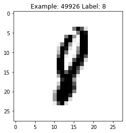

```python
display_digit(ran.randint(0, x_train.shape[0]))
```

```python
sess = tf.Session()
# Input and output
x = tf.placeholder(tf.float32, shape=[None, 784]) # input image 28*28 = 784
y_ = tf.placeholder(tf.float32, shape=[None, 10]) #0-9 digits (10 classes)
# Model parameters
W = tf.Variable(tf.zeros([784, 10]))
b = tf.Variable(tf.zeros([10]))
```

```python
y = tf.nn.softmax(tf.matmul(x,W) + b)
```

```python
init = tf.global_variables_initializer()
sess.run(init)
```

```python
LEARNING_RATE = 0.1
cross_entropy = tf.reduce_mean(-tf.reduce_sum(y_ * tf.log(y),
reduction_indices=[1]))
training = tf.train.GradientDescentOptimizer(LEARNING_RATE).minimize(cross_entropy)
correct_prediction = tf.equal(tf.argmax(y,1), tf.argmax(y_,1))
accuracy = tf.reduce_mean(tf.cast(correct_prediction, tf.float32))
```

## Q4 - Write a few sentences about tf.train.GradientDescentOptimizer and tf.equal commands. What is the effect of tf.argmax().

tf.train.GradientDescentOptimizer - As we are training our model, we make use of an Optimizer which implements gradient descent algorithm. Gradient descent minimizes the cost function parametrized by model's parameters by updating the parameters in the opposite direct of the gradient. The minimize function averages out all loss functions into cost functions. The learning rate determines the size of the steps the algorithm takes to reach a minimum.

tf.equal - tf.equal compares two tensors to check if the elements in both tensors are equal. This function returns a tensor with each element of bool value 0 or 1 after comparision.

tf.argmax - returns index with the largest value across axes of a tensor. Calculates the maximum value of row / column, as we pass 2nd argument which is 1, indicates by row . and returns the subscript of the maximum value.

```python
TRAIN_STEPS = 250
for i in range(TRAIN_STEPS+1):
 sess.run(training, feed_dict={x: x_train, y_: y_train})
 if i%100 == 0:
        print('Training Step:' + str(i) + ' Accuracy = ' +str(sess.run(accuracy, feed_dict={x: x_test, y_: y_test})) + ' Loss = ' + str(sess.run(cross_entropy, {x: x_train, y_: y_train})))
```

```
Training Step:0 Accuracy = 0.6705 Loss = 2.1970637
Training Step:100 Accuracy = 0.8713 Loss = 0.6085837
Training Step:200 Accuracy = 0.8857 Loss = 0.49071002
```

## Q5- Explain this part of the code.

In the above code we can accuracy has improved from 67 percent to 88.5 percent as we have icreased number of runs. We have used for loop to increase train steps. AT every 100 steps thge accuracy has been improving by huge from step 0 to step 100 and but the accuracy has slightly improve from step 100 to step 200. Finally we are viasualizing the important parameters of the model by printing Training Steps and Accuracu

```python
# Input and output
X = tf.placeholder(tf.float32, shape=[None, 784]) # input image 28*28 = 784
Y_ = tf.placeholder(tf.float32, shape=[None, 10]) #0-9 digits (10 classes)
# Two hidden layers, output layer and their number of neurons (the last layer has 10 softmax neurons)
L = 100
M = 30
# tf.truncated_normal is a TensorFlow function that produces random values following the normal (Gaussian) distribution between -2*stddev and +2*stddev
W1 = tf.Variable(tf.truncated_normal([784, L], stddev=0.1)) # 784 = 28 * 28
B1 = tf.Variable(tf.zeros([L]))
W2 = tf.Variable(tf.truncated_normal([L, M], stddev=0.1))
B2 = tf.Variable(tf.zeros([M]))
W3 = tf.Variable(tf.truncated_normal([M, 10], stddev=0.1))
B3 = tf.Variable(tf.zeros([10]))
# The model
XX = tf.reshape(X, [-1, 784])
Y1 = tf.nn.sigmoid(tf.matmul(XX, W1) + B1)
Y2 = tf.nn.sigmoid(tf.matmul(Y1, W2) + B2)
Ylogits = tf.matmul(Y2, W3) + B3
Y = tf.nn.softmax(Ylogits)
```

```python
# cross-entropy loss function (= -sum(Y_i * log(Yi)) ), normalised for batches of 100 images
# TensorFlow provides the softmax_cross_entropy_with_logits function to avoid numerical stability
# problems with log(0) which is NaN
cross_entropy = tf.nn.softmax_cross_entropy_with_logits(logits=Ylogits,
labels=Y_)
cross_entropy = tf.reduce_mean(cross_entropy)*100
# accuracy of the trained model, between 0 (worst) and 1 (best)
correct_prediction = tf.equal(tf.argmax(Y, 1), tf.argmax(Y_, 1))
accuracy = tf.reduce_mean(tf.cast(correct_prediction, tf.float32))
```

[output not shown]

```python
# init
init = tf.global_variables_initializer()
sess = tf.Session()
sess.run(init)
```

```python
LEARNING_RATE = 0.01
#cross_entropy = tf.reduce_mean(-tf.reduce_sum(y_ * tf.log(y),reduction_indices=[1]))
training = tf.train.GradientDescentOptimizer(LEARNING_RATE).minimize(cross_entropy)
#correct_prediction = tf.equal(tf.argmax(y,1), tf.argmax(y_,1))
#accuracy = tf.reduce_mean(tf.cast(correct_prediction, tf.float32))
TRAIN_STEPS = 1000
for i in range(TRAIN_STEPS+1):
 sess.run(training, feed_dict={X: x_train, Y_: y_train})
 if i%100 == 0:
  print('Training Step:' + str(i) + ' Accuracy = ' + str(sess.run(accuracy, feed_dict={X: x_test, Y_: y_test})) + ' Loss = ' + str(sess.run(cross_entropy, {X: x_train, Y_: y_train})))
```

```
Training Step:0 Accuracy = 0.1135 Loss = 229.86896
Training Step:100 Accuracy = 0.7521 Loss = 88.742325
Training Step:200 Accuracy = 0.8305 Loss = 55.609303
Training Step:300 Accuracy = 0.896 Loss = 37.436024
Training Step:400 Accuracy = 0.9094 Loss = 32.052258
Training Step:500 Accuracy = 0.918 Loss = 28.407993
Training Step:600 Accuracy = 0.926 Loss = 25.51376
Training Step:700 Accuracy = 0.9333 Loss = 23.062708
Training Step:800 Accuracy = 0.9381 Loss = 20.94788
Training Step:900 Accuracy = 0.9439 Loss = 19.123055
Training Step:1000 Accuracy = 0.9501 Loss = 17.555355
```

```python
# Drop Out

# Input and output
X = tf.placeholder(tf.float32, shape=[None, 784]) # input image 28*28 = 784
Y_ = tf.placeholder(tf.float32, shape=[None, 10]) #0-9 digits (10 classes)
pkeep = tf.placeholder(tf.float32)
L = 100
M = 30
N = 60
O = 30
# tf.truncated_normal is a TensorFlow function that produces random values following the normal (Gaussian) distribution between -2*stddev and +2*stddev
W1 = tf.Variable(tf.truncated_normal([784, L], stddev=0.1)) # 784 = 28 * 28
B1 = tf.Variable(tf.ones([L])/10)
W2 = tf.Variable(tf.truncated_normal([L, M], stddev=0.1))
B2 = tf.Variable(tf.ones([M])/10)
W3 = tf.Variable(tf.truncated_normal([M, 10], stddev=0.1))
B3 = tf.Variable(tf.zeros([10]))
# The model
XX = tf.reshape(X, [-1, 784])
Y1 = tf.nn.relu(tf.matmul(XX, W1) + B1)
Y1d = tf.nn.dropout(Y1, pkeep)
Y2 = tf.nn.relu(tf.matmul(Y1, W2) + B2)
Y2d = tf.nn.dropout(Y2, pkeep)
Ylogits = tf.matmul(Y2d, W3) + B3
Y = tf.nn.softmax(Ylogits)
```

```
W0903 23:36:49.258615 4488177088 deprecation.py:506] From <ipython-input-18-e99b0634e8cc>:21: calling dropout (from tensorflow.python.ops.nn_ops) with keep_prob is deprecated and will be removed in a future version.
Instructions for updating:
Please use `rate` instead of `keep_prob`. Rate should be set to `rate = 1 - keep_prob`.
```

```python
# cross-entropy loss function (= -sum(Y_i * log(Yi)) ), normalised for batches of 100 images
# TensorFlow provides the softmax_cross_entropy_with_logits function to avoid numerical stability
# problems with log(0) which is NaN
cross_entropy = tf.nn.softmax_cross_entropy_with_logits_v2(logits=Ylogits,
labels=Y_)
cross_entropy = tf.reduce_mean(cross_entropy)*100
# accuracy of the trained model, between 0 (worst) and 1 (best)
correct_prediction = tf.equal(tf.argmax(Y, 1), tf.argmax(Y_, 1))
accuracy = tf.reduce_mean(tf.cast(correct_prediction, tf.float32))
# init
init = tf.global_variables_initializer()
sess = tf.Session()
sess.run(init)
LEARNING_RATE = 0.01
#cross_entropy = tf.reduce_mean(-tf.reduce_sum(y_ * tf.log(y),reduction_indices=[1]))
training = tf.train.GradientDescentOptimizer(LEARNING_RATE).minimize(cross_entropy)
#correct_prediction = tf.equal(tf.argmax(y,1), tf.argmax(y_,1))
#accuracy = tf.reduce_mean(tf.cast(correct_prediction, tf.float32))
TRAIN_STEPS = 1000
for i in range(TRAIN_STEPS+1):
 sess.run(training, feed_dict={X: x_train, Y_: y_train, pkeep: 0.75 })
 if i%100 == 0:
  print('Training Step:' + str(i) + ' Accuracy = ' + str(sess.run(accuracy, feed_dict={X: x_test, Y_: y_test, pkeep: 1.0})) + ' Loss = ' + str(sess.run(cross_entropy, {X: x_train, Y_: y_train , pkeep: 0.75})))
```

```
Training Step:0 Accuracy = 0.2365 Loss = 223.82202
Training Step:100 Accuracy = 0.9232 Loss = 35.194233
Training Step:200 Accuracy = 0.9502 Loss = 21.460415
Training Step:300 Accuracy = 0.9608 Loss = 16.08684
Training Step:400 Accuracy = 0.9671 Loss = 13.346131
Training Step:500 Accuracy = 0.9708 Loss = 11.578905
Training Step:600 Accuracy = 0.207 Loss = 956.1568
Training Step:700 Accuracy = 0.5231 Loss = 150.28304
Training Step:800 Accuracy = 0.922 Loss = 49.248466
Training Step:900 Accuracy = 0.9392 Loss = 34.362835
Training Step:1000 Accuracy = 0.9478 Loss = 29.61813
```

## Step 3. Stochastic Gradient Descent

```python
X = tf.placeholder(tf.float32, shape=[None, 784]) # input image 28*28 = 784
Y_ = tf.placeholder(tf.float32, shape=[None, 10]) #0-9 digits (10 classes)

pkeep = tf.placeholder(tf.float32)
L = 100
M = 30
N = 60
O = 30

W1 = tf.Variable(tf.truncated_normal([784, L], stddev=0.1)) # 784 = 28 * 28
B1 = tf.Variable(tf.ones([L])/10)
W2 = tf.Variable(tf.truncated_normal([L, M], stddev=0.1))
B2 = tf.Variable(tf.ones([M])/10)
W3 = tf.Variable(tf.truncated_normal([M, N], stddev=0.1))
B3 = tf.Variable(tf.ones([N])/10)
W4 = tf.Variable(tf.truncated_normal([N, O], stddev=0.1))
B4 = tf.Variable(tf.ones([O])/10)
W5 = tf.Variable(tf.truncated_normal([O, 10], stddev=0.1))
B5 = tf.Variable(tf.zeros([10]))


# The model
XX = tf.reshape(X, [-1, 784])
Y1 = tf.nn.relu(tf.matmul(XX, W1) + B1)
Y1d = tf.nn.dropout(Y1, pkeep)
Y2 = tf.nn.relu(tf.matmul(Y1, W2) + B2)
Y2d = tf.nn.dropout(Y2, pkeep)
Y3 = tf.nn.relu(tf.matmul(Y2, W3) + B3)
Y3d = tf.nn.dropout(Y3, pkeep)
Y4 = tf.nn.relu(tf.matmul(Y3, W4) + B4)
Y4d = tf.nn.dropout(Y4, pkeep)
Ylogits = tf.matmul(Y4d, W5) + B5
Y = tf.nn.softmax(Ylogits)
```

```python
# cross-entropy loss function (= -sum(Y_i * log(Yi)) ), normalised for batches of 100 images
# TensorFlow provides the softmax_cross_entropy_with_logits function to avoid numerical stability
# problems with log(0) which is NaN
cross_entropy = tf.nn.softmax_cross_entropy_with_logits_v2(logits=Ylogits, labels=Y_)
cross_entropy = tf.reduce_mean(cross_entropy)*100

# accuracy of the trained model, between 0 (worst) and 1 (best)
correct_prediction = tf.equal(tf.argmax(Y, 1), tf.argmax(Y_, 1))
accuracy = tf.reduce_mean(tf.cast(correct_prediction, tf.float32))

# init
init = tf.global_variables_initializer()
sess = tf.Session()
sess.run(init)
LEARNING_RATE = 0.01

#cross_entropy = tf.reduce_mean(-tf.reduce_sum(y_ * tf.log(y),reduction_indices=[1]))
training = tf.train.GradientDescentOptimizer(LEARNING_RATE).minimize(cross_entropy)

#correct_prediction = tf.equal(tf.argmax(y,1), tf.argmax(y_,1))
#accuracy = tf.reduce_mean(tf.cast(correct_prediction, tf.float32))

TRAIN_STEPS = 2200
for i in range(TRAIN_STEPS+1):
    x_batch , y_batch = mnist.train.next_batch(200)
    sess.run(training, feed_dict={X: x_batch, Y_: y_batch, pkeep: 0.75 })
    if i%100 == 0:
        print('Training Step:' + str(i) + ' Accuracy = ' +
    str(sess.run(accuracy, feed_dict={X: x_test, Y_: y_test, pkeep: 1.0})) +
    ' Loss = ' + str(sess.run(cross_entropy, {X: x_train, Y_: y_train , pkeep: 0.75})))
```

```
Training Step:0 Accuracy = 0.101 Loss = 229.4806
Training Step:100 Accuracy = 0.5808 Loss = 106.90505
Training Step:200 Accuracy = 0.8203 Loss = 57.72131
Training Step:300 Accuracy = 0.9289 Loss = 32.204884
Training Step:400 Accuracy = 0.9408 Loss = 25.430462
Training Step:500 Accuracy = 0.9276 Loss = 28.771135
Training Step:600 Accuracy = 0.8492 Loss = 63.101917
Training Step:700 Accuracy = 0.9426 Loss = 24.251698
Training Step:800 Accuracy = 0.9587 Loss = 16.861847
Training Step:900 Accuracy = 0.9498 Loss = 18.771595
Training Step:1000 Accuracy = 0.9598 Loss = 14.615652
Training Step:1100 Accuracy = 0.958 Loss = 13.629139
Training Step:1200 Accuracy = 0.9663 Loss = 11.461771
Training Step:1300 Accuracy = 0.9669 Loss = 10.709483
Training Step:1400 Accuracy = 0.9684 Loss = 10.069449
Training Step:1500 Accuracy = 0.9612 Loss = 13.274233
Training Step:1600 Accuracy = 0.9658 Loss = 10.276957
Training Step:1700 Accuracy = 0.9695 Loss = 9.135656
Training Step:1800 Accuracy = 0.965 Loss = 9.8132715
Training Step:1900 Accuracy = 0.9678 Loss = 8.530808
Training Step:2000 Accuracy = 0.9666 Loss = 8.321817
Training Step:2100 Accuracy = 0.9707 Loss = 7.95092
Training Step:2200 Accuracy = 0.9643 Loss = 10.064715
```

------END OF LAB1------